# Trabajo Grupal 4

Jose Castañeda Chilon, Jose Joselito Carhuaricra Cusipuma, Joaquín Antonio Castañón Vilca

## Descripción

El conjunto de datos en cuestión trata sobre la lesión hepática (daño hepático) Incluye un marco de datos de predictores biológicos relacionados con el daño hepático bio, un marco de datos de predictores químicos relacionados con la chem y la variable de respuesta que nos interesa, la lesión. Si un modelo se puede ajustar adecuadamente, ese modelo podría usarse para detectar compuestos dañinos en el futuro.

## Librerías utilizadas

Las librerías que se van a utilizar para el análisis se presentan a continuación:

```r
library(caret)
library(pROC)
library(AppliedPredictiveModeling)
library(glmnet)
library(pamr)
data(hepatic)
```

Antes de ajustar un modelo, siempre es necesario preprocesar los datos. Para los algoritmos de clasificación lineal, esto significa:

- Remove near zero variance predictor variables/ near-zero variance) predictors.
- Remove collinear variables.

```r
bio_zerovar <- nearZeroVar(bio)
bio_collinear <- findLinearCombos(cov(bio))$remove
bio <- bio[, -c(bio_zerovar, bio_collinear)]
```

Eliminar las variable problemáticas para ‘chem’ dataframe

```r
chem_zerovar <- nearZeroVar(chem)
chem_collinear <- findLinearCombos(chem)$remove
chem <- chem[, -c(chem_zerovar, chem_collinear)]
```

La variable de respuesta a la lesión a la que me adapto tiene tres clases: “Ninguna”, “Leve” y “Severa”. Si la variable de respuesta tiene demasiadas clases, se puede recortar (algo subjetivamente). Por conveniencia, decido dividir las lesiones en 2 clases: “Sí” o “No”, donde cuento las lesiones leves como “No”. (Advertencia: esto puede influir negativamente en la predicción, por lo que en el futuro me aseguraré de probar las predicciones de probabilidad de varias clases).

```r
##Collapse response into "Yes" or "No" values
lut <- c("None" = "No", "Mild" = "No", "Severe" = "Yes")
injury2 <- factor(unname(lut[injury]))
```

Ahora debería considerar otras preguntas

- Como particionar la base con clases no balanceadas (“No” supera con creces los valores de “Sí” en lesiones.)
- Como validar los resultados del modelo
- qué métrica maximiza el mejor modelo

Por suerte con la función “createDataPartition” se puede realizar la partición de la base automaticamente usando muestras estratificadas para Clases no balanceadas.

Para validación se decide que el modelo tenga una valdiación cruzada con 10 folds repetitivos la cual será especificado en el “traincontrol”.Aunque el primer modelo no necesitará validación cruzada, los demás sí por ello se usará el mismo control para cada modelo.

```r
set.seed(1234)

##Partition the data with stratified sampling
training <- createDataPartition(injury2, p = .8, list = FALSE)
##Partition train and test sets for bio data
bio_train <- bio[training, ]
bio_test <- bio[-training, ]
##Partition for train and test sets for chemical data
chem_train <- chem[training, ]
chem_test <- chem[-training, ]
##Partition for the train and test sets for the response variable
injury_train <- injury2[training]
injury_test <- injury2[-training]
## Set training control for model building
ctrl <- trainControl(method = "repeatedcv", 10, repeats = 10, summaryFunction = twoClassSummary, classProbs = TRUE, savePredictions = TRUE)
```

s importante decidir el que objetivo tendrá las métricas de Accuracy, Sensitivity, or Specificity tendrá el modelo. Para ello es necesario saber cual es la variable “positiva” desde la perspectiva de caret.

Caret escoje el primer clase de factor como positivo la cual corresponde a “no” en el vector “injury”. Por lo tanto, Sensitivity corresponde a la cantidad de valores “no” correctamente predichos, mientras que la Specificity corresponde a los valores “si” correctamente predichos.

El primer modelo es un clasificador que utiliza análisis discriminante lineal donde se aplica un modelo tanto para los indicadores biológicos como para los indicadores químicos, para ver cuáles tienen mejor poder predicativo.

```r
bio_lda <- train(bio_train, injury_train, method = "lda", trControl = ctrl, metric = "Spec")
chem_lda <- train(chem_train, injury_train, method = "lda", trControl = ctrl, metric = "Spec")
##Generate LDA model predictions for bio indicator test set
bio_lda_pred <- predict(bio_lda, bio_test)
##Generate confusion matrix to show results
confusionMatrix(bio_lda_pred, injury_test, positive = "No")
```

```
#> Confusion Matrix and Statistics
#>
#>           Reference
#> Prediction No Yes
#>        No  39   5
#>        Yes 11   1
#>
#>                Accuracy : 0.7143
#>                  95% CI : (0.5779, 0.827)
#>     No Information Rate : 0.8929
#>     P-Value [Acc > NIR] : 0.9999
#>
#>                   Kappa : -0.037
#>
#>  Mcnemar's Test P-Value : 0.2113
#>
#>             Sensitivity : 0.78000
#>             Specificity : 0.16667
#>          Pos Pred Value : 0.88636
#>          Neg Pred Value : 0.08333
#>              Prevalence : 0.89286
#>          Detection Rate : 0.69643
#>    Detection Prevalence : 0.78571
#>       Balanced Accuracy : 0.47333
#>
#>        'Positive' Class : No
#>
```

```r
##Chem predictor LDA model
chem_lda_pred <- predict(chem_lda, chem_test)
##confusion matrix
confusionMatrix(chem_lda_pred, injury_test, positive = "No")
```

```
#> Confusion Matrix and Statistics
#>
#>           Reference
#> Prediction No Yes
#>        No  46   5
#>        Yes  4   1
#>
#>                Accuracy : 0.8393
#>                  95% CI : (0.7167, 0.9238)
#>     No Information Rate : 0.8929
#>     P-Value [Acc > NIR] : 0.9278
#>
#>                   Kappa : 0.0935
#>
#>  Mcnemar's Test P-Value : 1.0000
#>
#>             Sensitivity : 0.9200
#>             Specificity : 0.1667
#>          Pos Pred Value : 0.9020
#>          Neg Pred Value : 0.2000
#>              Prevalence : 0.8929
#>          Detection Rate : 0.8214
#>    Detection Prevalence : 0.9107
#>       Balanced Accuracy : 0.5433
#>
#>        'Positive' Class : No
#>
```

```r
bio_plr <- train(bio_train, injury_train, method = "glmnet", family = "binomial", metric = "Spec", tuneLength = 2,
                 trControl = ctrl)
chem_plr <- train(chem_train, injury_train, method = "glmnet", family = "binomial", metric = "Spec", tuneLength = 2, trControl = ctrl)
bio_plr_pred <- predict(bio_plr, bio_test)

confusionMatrix(bio_plr_pred, injury_test, positive = "No")
```

```
#> Confusion Matrix and Statistics
#>
#>           Reference
#> Prediction No Yes
#>        No  38   5
#>        Yes 12   1
#>
#>                Accuracy : 0.6964
#>                  95% CI : (0.559, 0.8122)
#>     No Information Rate : 0.8929
#>     P-Value [Acc > NIR] : 1.0000
#>
#>                   Kappa : -0.0485
#>
#>  Mcnemar's Test P-Value : 0.1456
#>
#>             Sensitivity : 0.76000
#>             Specificity : 0.16667
#>          Pos Pred Value : 0.88372
#>          Neg Pred Value : 0.07692
#>              Prevalence : 0.89286
#>          Detection Rate : 0.67857
#>    Detection Prevalence : 0.76786
#>       Balanced Accuracy : 0.46333
#>
#>        'Positive' Class : No
#>
```

Esta regresión logística penalizada no funciona tan bien como el análisis discriminante lineal simple para los predictores biológicos.

```r
chem_plr_pred <- predict(chem_plr, chem_test)
confusionMatrix(chem_plr_pred, injury_test, positive = "No")
```

```
#> Confusion Matrix and Statistics
#>
#>           Reference
#> Prediction No Yes
#>        No  44   5
#>        Yes  6   1
#>
#>                Accuracy : 0.8036
#>                  95% CI : (0.6757, 0.8977)
#>     No Information Rate : 0.8929
#>     P-Value [Acc > NIR] : 0.9858
#>
#>                   Kappa : 0.0435
#>
#>  Mcnemar's Test P-Value : 1.0000
#>
#>             Sensitivity : 0.8800
#>             Specificity : 0.1667
#>          Pos Pred Value : 0.8980
#>          Neg Pred Value : 0.1429
#>              Prevalence : 0.8929
#>          Detection Rate : 0.7857
#>    Detection Prevalence : 0.8750
#>       Balanced Accuracy : 0.5233
#>
#>        'Positive' Class : No
#>
```

La regresión logística penalizada es aún peor para los predictores químicos. Claramente, este no es un modelo sólido para capturar la estructura de los datos para el patrón que estamos buscando.

Ahora, para ajustar un modelo de regresión de mínimos cuadrados parciales.

```r
bio_pls <- train(bio_train, injury_train, method = "pls", trControl = ctrl, metric = "Spec", tuneLength = 2)

chem_pls <- train(chem_train, injury_train, method = "pls", trControl = ctrl, metric = "Spec", tuneLength = 2)
bio_pls_pred <- predict(bio_pls, bio_test)

confusionMatrix(bio_pls_pred, injury_test, positive = "No")
```

```
#> Confusion Matrix and Statistics
#>
#>           Reference
#> Prediction No Yes
#>        No  50   6
#>        Yes  0   0
#>
#>                Accuracy : 0.8929
#>                  95% CI : (0.7812, 0.9597)
#>     No Information Rate : 0.8929
#>     P-Value [Acc > NIR] : 0.60647
#>
#>                   Kappa : 0
#>
#>  Mcnemar's Test P-Value : 0.04123
#>
#>             Sensitivity : 1.0000
#>             Specificity : 0.0000
#>          Pos Pred Value : 0.8929
#>          Neg Pred Value :    NaN
#>              Prevalence : 0.8929
#>          Detection Rate : 0.8929
#>    Detection Prevalence : 1.0000
#>       Balanced Accuracy : 0.5000
#>
#>        'Positive' Class : No
#>
```

```r
chem_pls_pred <- predict(chem_pls, chem_test, probability = TRUE)

confusionMatrix(chem_pls_pred, injury_test, positive = "No")
```

```
#> Confusion Matrix and Statistics
#>
#>           Reference
#> Prediction No Yes
#>        No  50   6
#>        Yes  0   0
#>
#>                Accuracy : 0.8929
#>                  95% CI : (0.7812, 0.9597)
#>     No Information Rate : 0.8929
#>     P-Value [Acc > NIR] : 0.60647
#>
#>                   Kappa : 0
#>
#>  Mcnemar's Test P-Value : 0.04123
#>
#>             Sensitivity : 1.0000
#>             Specificity : 0.0000
#>          Pos Pred Value : 0.8929
#>          Neg Pred Value :    NaN
#>              Prevalence : 0.8929
#>          Detection Rate : 0.8929
#>    Detection Prevalence : 1.0000
#>       Balanced Accuracy : 0.5000
#>
#>        'Positive' Class : No
#>
```

```r
bio_centroid <- train(bio_train, injury_train, method = "pam",

                      trControl = ctrl, preProcess = c("center", "scale"), metric = "Spec", tuneLength = 2)
```

[output not shown]

```r
chem_centroid <- train(chem_train, injury_train, method = "pam",

                       trControl = ctrl, preProcess = c("center", "scale"), metric = "Spec", tuneLength = 2)
```

[output not shown]

```r
bio_centroid_pred <- predict(bio_centroid, bio_test)
chem_centroid_pred <- predict(chem_centroid, chem_test)
confusionMatrix(bio_centroid_pred, injury_test, positive = "No")
```

```
#> Confusion Matrix and Statistics
#>
#>           Reference
#> Prediction No Yes
#>        No  50   6
#>        Yes  0   0
#>
#>                Accuracy : 0.8929
#>                  95% CI : (0.7812, 0.9597)
#>     No Information Rate : 0.8929
#>     P-Value [Acc > NIR] : 0.60647
#>
#>                   Kappa : 0
#>
#>  Mcnemar's Test P-Value : 0.04123
#>
#>             Sensitivity : 1.0000
#>             Specificity : 0.0000
#>          Pos Pred Value : 0.8929
#>          Neg Pred Value :    NaN
#>              Prevalence : 0.8929
#>          Detection Rate : 0.8929
#>    Detection Prevalence : 1.0000
#>       Balanced Accuracy : 0.5000
#>
#>        'Positive' Class : No
#>
```

```r
confusionMatrix(chem_centroid_pred, injury_test, positive = "No")
```

```
#> Confusion Matrix and Statistics
#>
#>           Reference
#> Prediction No Yes
#>        No  49   6
#>        Yes  1   0
#>
#>                Accuracy : 0.875
#>                  95% CI : (0.7593, 0.9482)
#>     No Information Rate : 0.8929
#>     P-Value [Acc > NIR] : 0.7522
#>
#>                   Kappa : -0.0316
#>
#>  Mcnemar's Test P-Value : 0.1306
#>
#>             Sensitivity : 0.9800
#>             Specificity : 0.0000
#>          Pos Pred Value : 0.8909
#>          Neg Pred Value : 0.0000
#>              Prevalence : 0.8929
#>          Detection Rate : 0.8750
#>    Detection Prevalence : 0.9821
#>       Balanced Accuracy : 0.4900
#>
#>        'Positive' Class : No
#>
```

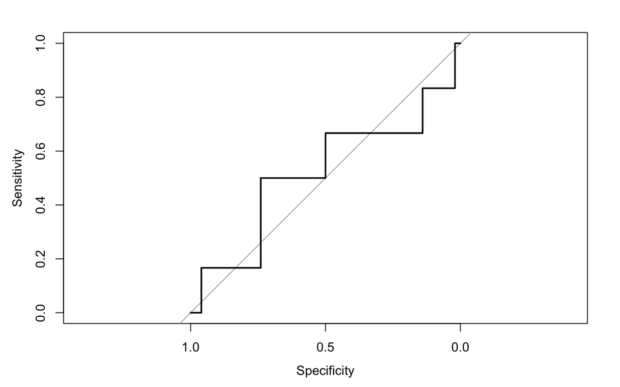

```r
predictions_bio_lda <- predict(bio_lda, bio_test, type = "prob")

pROC::plot.roc(injury_test, predictions_bio_lda$Yes)
```

Sin embargo, el área debajo de la curva no es tan alta como quisieramos. Quizás en el futuro sea revisado estos datos y con la finalidad de que se opte por una diferente manera de predecir lesiones.